# R per l’analisi statistica multivariata

Unità E: tabelle di contingenza

## Dati del titanic

I dati `titanic` fanno riferimento al tragico incidente navale avvenuto nel 1912. Questo dataset è inoltre descritto nell’[Unità O](https://tommasorigon.github.io/StatI/slides/sl_O.pdf) del corso Statistica I. L’opzione `sep = ","` indica che i dati sono separati da una virgola.

```r
path <- "https://tommasorigon.github.io/introR/data/titanic.csv"
titanic <- read.table(path, header = TRUE, sep = ",", stringsAsFactors = TRUE) # Scarica il file da internet

str(titanic)
'data.frame':   1316 obs. of  2 variables:
 $ Salvato: Factor w/ 2 levels "No","Si": 2 2 2 2 2 2 2 2 2 2 ...
 $ Classe : Factor w/ 3 levels "I","II","III": 1 1 1 1 1 1 1 1 1 1 ...
```

Come fatto precedentemente, otteniamo le frequenze (assolute e relative) per la variabile classe.

```r
freq_ass <- table(titanic$Classe)
freq_rel <- freq_ass / sum(freq_ass)

tab <- cbind(freq_ass, freq_rel)
colnames(tab) <- c(
  "Frequenze assolute",
  "Frequenze relative"
)

library(knitr)
kable(tab, digits = 3)
```

|  | Frequenze assolute | Frequenze relative |
| --- | --- | --- |
| I | 325 | 0.247 |
| II | 285 | 0.217 |
| III | 706 | 0.536 |

## Diagramma a barre

Il diagramma a barre è una rappresentazione grafica delle frequenze (assolute o relative), per variabili qualitative. In **R** è possibile ottenerlo tramite il comando `barplot`.

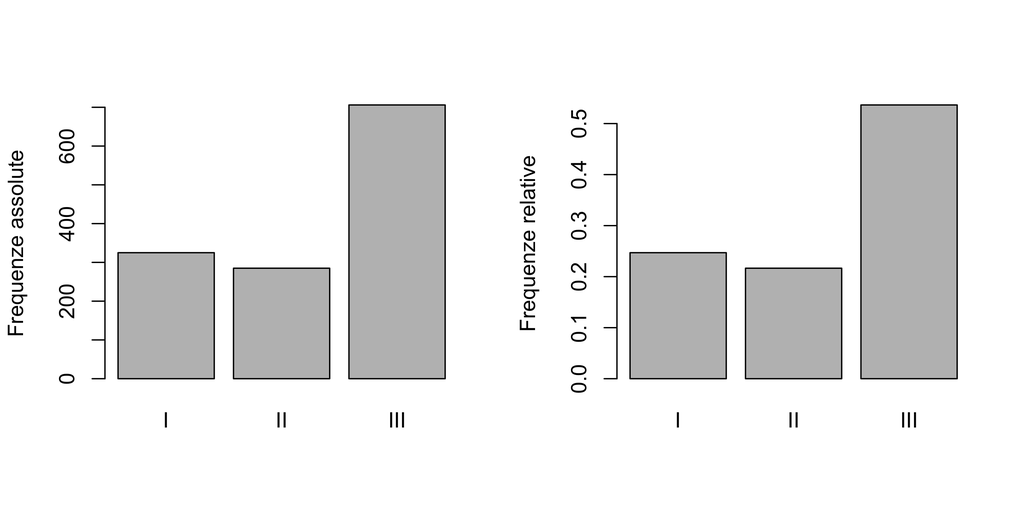

```r
par(mfrow = c(1, 2))
barplot(freq_ass, ylab = "Frequenze assolute") # Grafico frequenze assolute
barplot(freq_rel, ylab = "Frequenze relative") # Grafico frequenze relative
```

## Tabella a doppia entrata

La **tabella a doppia entrata** viene utilizzata per rappresentare una **distribuzione di frequenza congiunta** di due variabili.

Rappresentiamo qui di seguito la tabella che mette i relazioni si sopravvissuti `Salvato`, con la classe di appartenenza `Classe`, del dataset `titanic`.

```r
tab <- table(titanic$Salvato, titanic$Classe)
kable(tab)
```

|  | I | II | III |
| --- | --- | --- | --- |
| No | 122 | 167 | 528 |
| Si | 203 | 118 | 178 |

Possiamo anche aggiungere le frequenze assolute marginali come segue:

```r
tab_margins <- addmargins(tab)
kable(tab_margins)
```

|  | I | II | III | Sum |
| --- | --- | --- | --- | --- |
| No | 122 | 167 | 528 | 817 |
| Si | 203 | 118 | 178 | 499 |
| Sum | 325 | 285 | 706 | 1316 |

### Frequenze relative congiunte e relative marginali

Le **frequenze relative congiunte** si ottengono dividendo le frequenze congiunte assolute per il totale delle osservazioni. Pertanto, in **R** eseguiamo

```r
tab_rel <- prop.table(tab) # Comando alternativo: table(tab) / sum(tab)
kable(tab_rel, digits = 3)
```

|  | I | II | III |
| --- | --- | --- | --- |
| No | 0.093 | 0.127 | 0.401 |
| Si | 0.154 | 0.090 | 0.135 |

Esattamente come nel caso precedente, possiamo aggiungere le frequenze relative marginali.

```r
tab_rel_margins <- addmargins(tab_rel)
kable(tab_rel_margins)
```

|  | I | II | III | Sum |
| --- | --- | --- | --- | --- |
| No | 0.0927052 | 0.1268997 | 0.4012158 | 0.6208207 |
| Si | 0.1542553 | 0.0896657 | 0.1352584 | 0.3791793 |
| Sum | 0.2469605 | 0.2165653 | 0.5364742 | 1.0000000 |

## Diagramma a barre per tabelle a doppia entrata

A partire dalle tabelle a doppia entrata mostrate, è possibile rappresentare graficamente le distribuzioni di frequenza per mettere in evidenza la relazione tra le due variabili, utilizzando i diagrammi a barre accostate e sovrapposte.

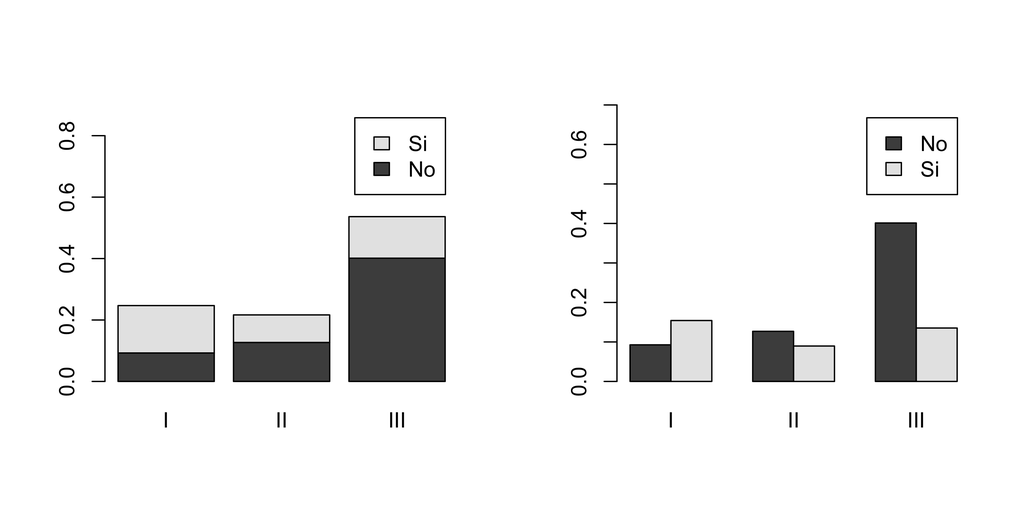

```r
par(mfrow = c(1, 2))
barplot(tab_rel,
  legend = rownames(tab_rel),
  ylim = c(0, 0.9)
)

barplot(tab_rel,
  beside = TRUE,
  legend = rownames(tab_rel),
  ylim = c(0, 0.7)
)
```

## Frequenze condizionate

Le **frequenze subordinate (o condizionate)** per riga o per colonna rappresentano la distribuzione di frequenze relative di una variabile per una fissata modalità dell’altra variabile. Esse permettono di identificare facilmente eventuali relazioni tra le variabili.

```r
# Frequenze condizionate 1
tab_cond1 <- addmargins(prop.table(tab, 1), 2)
kable(tab_cond1, digits = 3)
```

|  | I | II | III | Sum |
| --- | --- | --- | --- | --- |
| No | 0.149 | 0.204 | 0.646 | 1 |
| Si | 0.407 | 0.236 | 0.357 | 1 |

```r
# Frequenze condizionate 2
tab_cond2 <- addmargins(prop.table(tab, 2), 1)
kable(tab_cond2, digits = 3)
```

|  | I | II | III |
| --- | --- | --- | --- |
| No | 0.375 | 0.586 | 0.748 |
| Si | 0.625 | 0.414 | 0.252 |
| Sum | 1.000 | 1.000 | 1.000 |

Da quest’ultima tabella è decisamente evidente che i viaggiatori della I classe hanno ricevuto al momento del disastro un trattamento preferenziale.

Otteniamo infine il grafico delle precedenti tabelle.

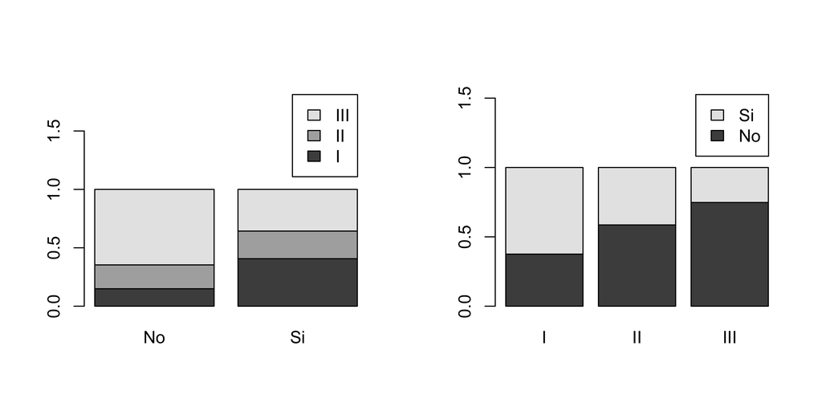

```r
par(mfrow = c(1, 2))
barplot(t(prop.table(tab, 1)),
  legend = colnames(tab),
  ylim = c(0, 1.9)
)

barplot(prop.table(tab, 2),
  legend = rownames(tab),
  ylim = c(0, 1.6)
)
```